# Analisi serie storica

Jacopo Lot

## Caricamento serie storica

```r
library(quantmod)
getSymbols("WFRBLB50085", src="FRED")
```

[output not shown]

```
## [1] "WFRBLB50085"
```

## Descrizione dataset

Il dataset riguarda la quantità di attività finanziarie detenuta dalle famiglie statunitensi che si trovano tra il 1° e il 50° percentile di ricchezza. La serie storica mostra le stime trimestrali di questa quantità, a partire dal terzo trimestre del 1989 e fino al trimestre più recente, che è il quarto trimestre del 2021.

Le stime trimestrali sono contenute nei conti finanziari distributivi, Distributional Financial Accounts, che integrano due prodotti di dati resi disponibili dalla Board of Governors della Federal Reserve, cioè dal Consiglio di Amministrazione della FED: i conti finanziari degli Stati Uniti, che forniscono dati trimestrali sui bilanci aggregati dei principali settori dell’economia statunitense, e il Survey of Consumer Finances, che fornisce microdati a cadenza triennale sulle attività e passività di un campione rappresentativo di famiglie statunitensi.

In particolare, i conti finanziari distributivi utilizzano le informazioni tratte dal Survey of Consumer Finances per allocare le misure aggregate dei conti finanziari di attività e passività a diverse sottopopolazioni suddivise in base a diversi livelli di reddito e ricchezza.

## Analisi grafica preliminare

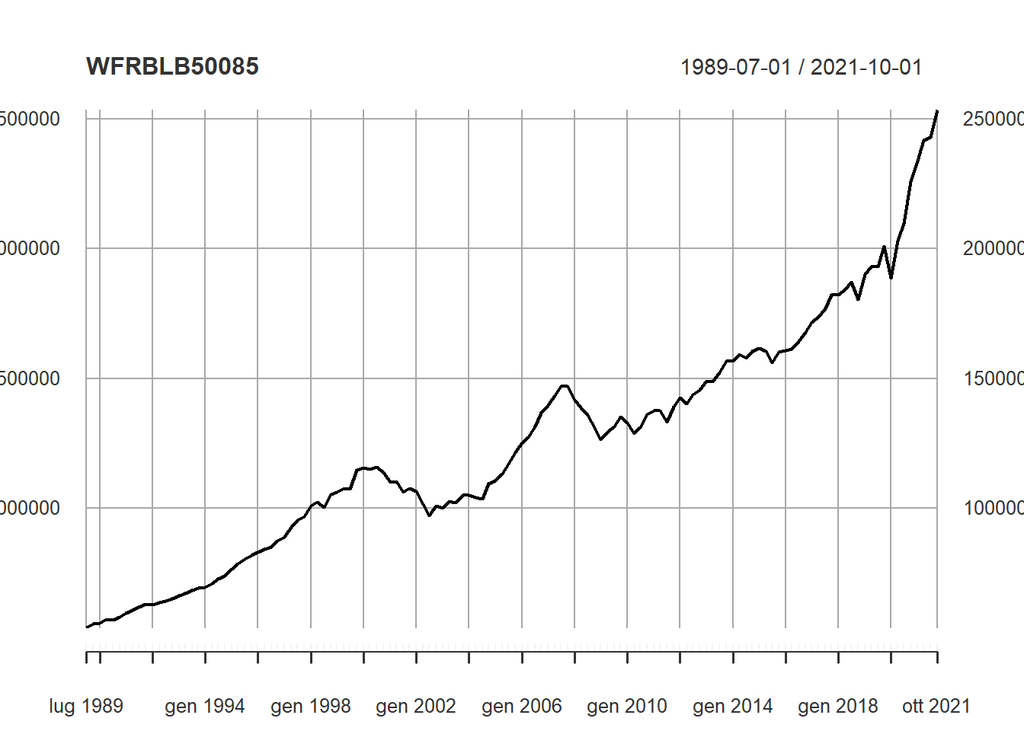

- Il trend potrebbe essere descritto da un modello di trend quadratico crescente.
- Essendo il dato trimestrale ci possiamo attendere di osservare una stagionalità di periodo 4.

## Trend e stagionalità

### Trend polinomiali

La lunghezza della serie è:

```r
length(WFRBLB50085)
```

```
## [1] 130
```

Ora provo a stimare diversi modelli di trend polinomiali per vedere quale si adatta meglio a descrivere il trend della serie storica in analisi:

```r
summary(lm(WFRBLB50085 ~ I(1:130)))
```

```
##
## Call:
## lm(formula = WFRBLB50085 ~ I(1:130))
##
## Residuals:
##     Min      1Q  Median      3Q     Max
## -187750  -99003   -2623   40314  540750
##
## Coefficients:
##             Estimate Std. Error t value Pr(>|t|)
## (Intercept) 491838.0    21811.3   22.55   <2e-16 ***
## I(1:130)     11548.8      288.9   39.97   <2e-16 ***
## ---
## Signif. codes:  0 '***' 0.001 '**' 0.01 '*' 0.05 '.' 0.1 ' ' 1
##
## Residual standard error: 123600 on 128 degrees of freedom
## Multiple R-squared:  0.9258, Adjusted R-squared:  0.9252
## F-statistic:  1598 on 1 and 128 DF,  p-value: < 2.2e-16
```

Osservando i risultati ottenuti si può dire che il trend lineare si adatta molto bene alla descrizione del trend della serie, dato che R quadro adjusted è pari a 0,9252. Inoltre, tutti i coefficienti sono significaivamente diversi da 0.

Per verificare che il trend lineare descriva la serie storica in modo accettabile faccio un’analisi dei residui del modello lineare:

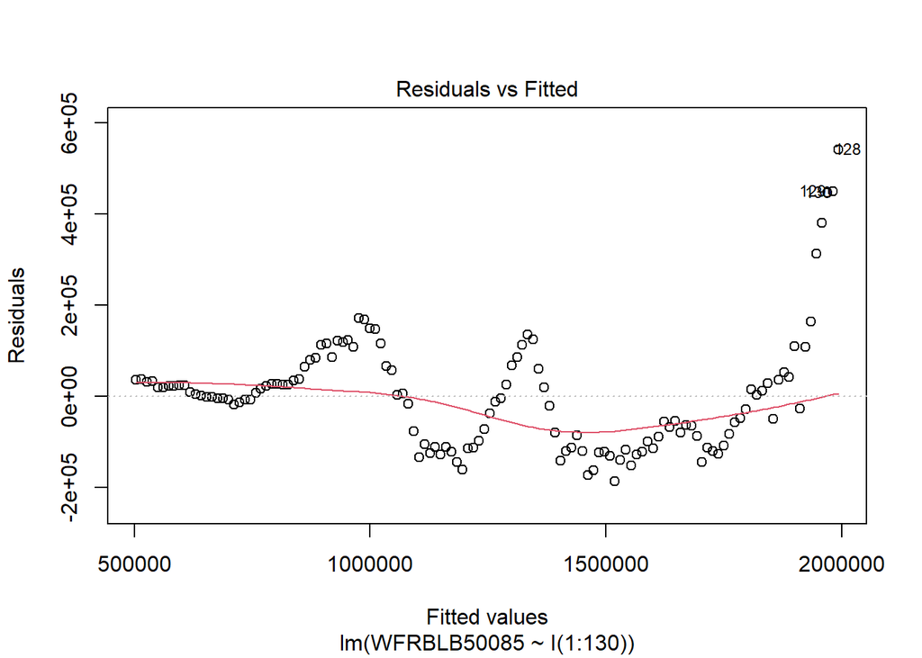

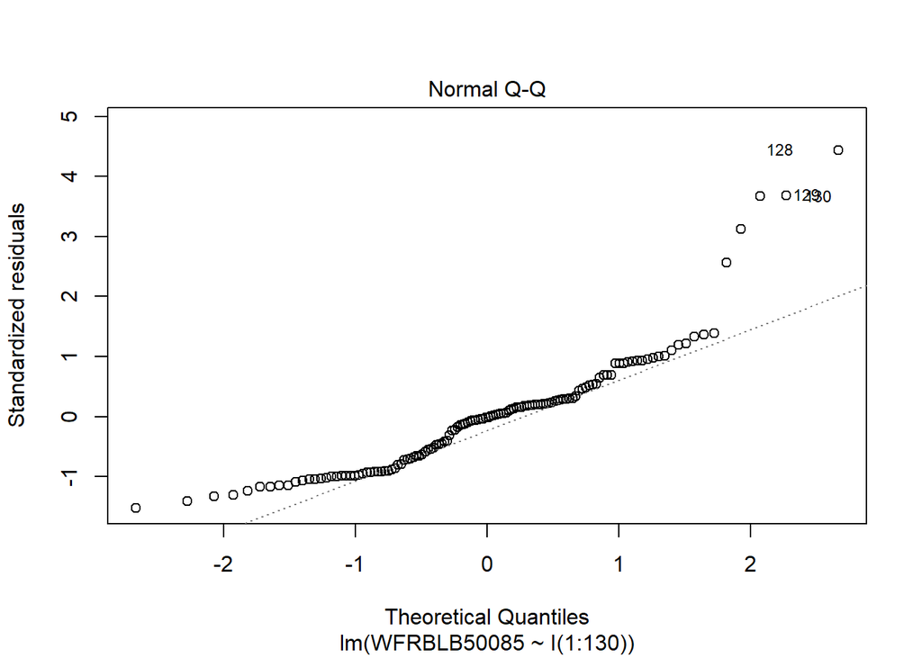

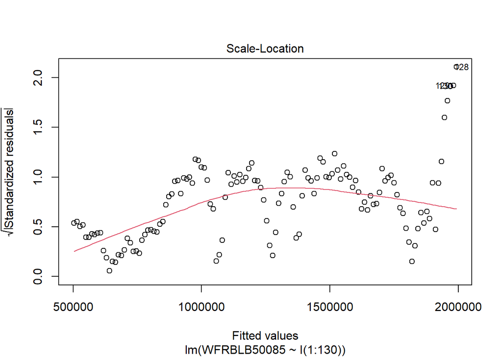

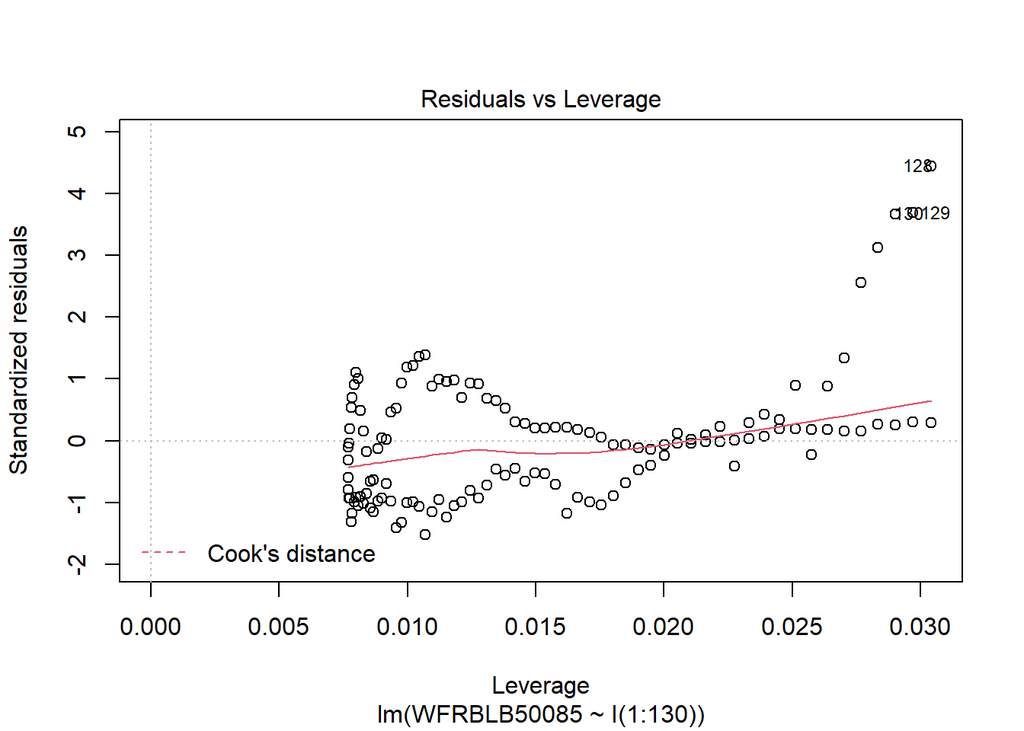

```r
pol1 <- lm(WFRBLB50085 ~ I(1:130))
resLinMod <- lm(WFRBLB50085 ~ I(1:130))
plot(resLinMod)
```

Osservando i grafici diagnostici si può notare che:

- Il grafico “Residual vs Fitted” mostra un andamento dei residui che non è casuale ma sembra influenzato dalla componente stagionale
- Il grafico “Normal Q-Q” presenta dei valori che sembrano discostarsi dai quantili della normale
- Il grafico “Residual vs Leverage” mostra la distribuzione dei valori anomali.In questo caso, sembrano esserci numerosi valori anomali.

Quindi, proseguo stimando altri modelli di trend polinomiali per osservare l’andamento dei valori di R quadro adjusted:

```r
pol2 <- lm(WFRBLB50085 ~ I(1:130)+I((1:130)^2))

summary(pol2)
```

```
##
## Call:
## lm(formula = WFRBLB50085 ~ I(1:130) + I((1:130)^2))
##
## Residuals:
##     Min      1Q  Median      3Q     Max
## -150897  -74179  -43802   54049  422272
##
## Coefficients:
##               Estimate Std. Error t value Pr(>|t|)
## (Intercept)  6.159e+05  2.975e+04  20.703  < 2e-16 ***
## I(1:130)     5.909e+03  1.048e+03   5.636 1.07e-07 ***
## I((1:130)^2) 4.305e+01  7.753e+00   5.553 1.57e-07 ***
## ---
## Signif. codes:  0 '***' 0.001 '**' 0.01 '*' 0.05 '.' 0.1 ' ' 1
##
## Residual standard error: 111300 on 127 degrees of freedom
## Multiple R-squared:  0.9403, Adjusted R-squared:  0.9394
## F-statistic:  1000 on 2 and 127 DF,  p-value: < 2.2e-16
```

Proseguo con la stima di altri modelli di trend polinomiali per osservare l’andamento di R quadro adjusted:

```r
pol3 <- lm(WFRBLB50085 ~ I(1:130)+I((1:130)^2)+I((1:130)^3))

summary(pol3)
```

```
##
## Call:
## lm(formula = WFRBLB50085 ~ I(1:130) + I((1:130)^2) + I((1:130)^3))
##
## Residuals:
##     Min      1Q  Median      3Q     Max
## -188656  -57670  -11495   42706  233837
##
## Coefficients:
##                Estimate Std. Error t value Pr(>|t|)
## (Intercept)   4.093e+05  2.968e+04  13.788  < 2e-16 ***
## I(1:130)      2.448e+04  1.955e+03  12.526  < 2e-16 ***
## I((1:130)^2) -3.101e+02  3.460e+01  -8.962 3.62e-15 ***
## I((1:130)^3)  1.797e+00  1.737e-01  10.349  < 2e-16 ***
## ---
## Signif. codes:  0 '***' 0.001 '**' 0.01 '*' 0.05 '.' 0.1 ' ' 1
##
## Residual standard error: 82180 on 126 degrees of freedom
## Multiple R-squared:  0.9677, Adjusted R-squared:  0.967
## F-statistic:  1260 on 3 and 126 DF,  p-value: < 2.2e-16
```

Il modello di trend cubico presenta un R quadro adjusted più alto rispetto ai precedenti modelli e i suoi coefficienti sono tutti significativamente diversi da 0.

```r
pol4 <- lm(WFRBLB50085 ~ I(1:130)+I((1:130)^2)+I((1:130)^3)+I((1:130)^4))

summary(pol4)
```

```
##
## Call:
## lm(formula = WFRBLB50085 ~ I(1:130) + I((1:130)^2) + I((1:130)^3) +
##     I((1:130)^4))
##
## Residuals:
##     Min      1Q  Median      3Q     Max
## -202021  -31968   -3063   43930  190910
##
## Coefficients:
##                Estimate Std. Error t value Pr(>|t|)
## (Intercept)   5.293e+05  3.371e+04  15.702  < 2e-16 ***
## I(1:130)      6.769e+03  3.536e+03   1.914  0.05790 .
## I((1:130)^2)  2.930e+02  1.092e+02   2.684  0.00826 **
## I((1:130)^3) -5.346e+00  1.250e+00  -4.277 3.73e-05 ***
## I((1:130)^4)  2.727e-02  4.734e-03   5.759 6.18e-08 ***
## ---
## Signif. codes:  0 '***' 0.001 '**' 0.01 '*' 0.05 '.' 0.1 ' ' 1
##
## Residual standard error: 73350 on 125 degrees of freedom
## Multiple R-squared:  0.9745, Adjusted R-squared:  0.9737
## F-statistic:  1194 on 4 and 125 DF,  p-value: < 2.2e-16
```

Il modello di trend polinomiale di grado 4 presenta un R squared più alto del precedente, ma il coefficiente di t non è significativamente diverso da 0.

```r
pol5 <- lm(WFRBLB50085 ~ I(1:130)+I((1:130)^2)+I((1:130)^3)+I((1:130)^4)+I((1:130)^5))

summary(pol5)
```

```
##
## Call:
## lm(formula = WFRBLB50085 ~ I(1:130) + I((1:130)^2) + I((1:130)^3) +
##     I((1:130)^4) + I((1:130)^5))
##
## Residuals:
##     Min      1Q  Median      3Q     Max
## -196543  -34070   -2243   43495  182459
##
## Coefficients:
##                Estimate Std. Error t value Pr(>|t|)
## (Intercept)   4.826e+05  4.088e+04  11.806  < 2e-16 ***
## I(1:130)      1.691e+04  6.221e+03   2.719  0.00749 **
## I((1:130)^2) -2.407e+02  2.915e+02  -0.826  0.41041
## I((1:130)^3)  5.456e+00  5.617e+00   0.971  0.33322
## I((1:130)^4) -6.532e-02  4.719e-02  -1.384  0.16880
## I((1:130)^5)  2.827e-04  1.434e-04   1.972  0.05088 .
## ---
## Signif. codes:  0 '***' 0.001 '**' 0.01 '*' 0.05 '.' 0.1 ' ' 1
##
## Residual standard error: 72510 on 124 degrees of freedom
## Multiple R-squared:  0.9753, Adjusted R-squared:  0.9743
## F-statistic: 978.3 on 5 and 124 DF,  p-value: < 2.2e-16
```

Il modello di trend polinomiale di grado 5 presenta un R quadro adjusted più elevato rispetto al modello precedente ma quasi tutti i suoi coefficienti non sono significativamente diversi da 0.

```r
pol6 <- lm(WFRBLB50085 ~ I(1:130)+I((1:130)^2)+I((1:130)^3)+I((1:130)^4)+I((1:130)^5)+I((1:130)^6))

summary(pol6)
```

```
##
## Call:
## lm(formula = WFRBLB50085 ~ I(1:130) + I((1:130)^2) + I((1:130)^3) +
##     I((1:130)^4) + I((1:130)^5) + I((1:130)^6))
##
## Residuals:
##     Min      1Q  Median      3Q     Max
## -165306  -36453   -3678   37727  205200
##
## Coefficients:
##                Estimate Std. Error t value Pr(>|t|)
## (Intercept)   5.995e+05  4.528e+04  13.240  < 2e-16 ***
## I(1:130)     -1.789e+04  9.389e+03  -1.905 0.059096 .
## I((1:130)^2)  2.355e+03  6.156e+02   3.825 0.000207 ***
## I((1:130)^3) -7.303e+01  1.752e+01  -4.168 5.75e-05 ***
## I((1:130)^4)  1.053e+00  2.425e-01   4.344 2.90e-05 ***
## I((1:130)^5) -7.219e-03  1.605e-03  -4.498 1.57e-05 ***
## I((1:130)^6)  1.909e-05  4.070e-06   4.690 7.15e-06 ***
## ---
## Signif. codes:  0 '***' 0.001 '**' 0.01 '*' 0.05 '.' 0.1 ' ' 1
##
## Residual standard error: 67060 on 123 degrees of freedom
## Multiple R-squared:  0.979,  Adjusted R-squared:  0.978
## F-statistic:   957 on 6 and 123 DF,  p-value: < 2.2e-16
```

Il modello di trend polinomiale di grado 6 presenta un R quadro adjusted più elevato rispetto al modello precedente ma il coefficiente di t non è significativamente diverso da 0.

```r
pol7 <- lm(WFRBLB50085 ~ I(1:130)+I((1:130)^2)+I((1:130)^3)+I((1:130)^4)+I((1:130)^5)+I((1:130)^6)+I((1:130)^7))

summary(pol7)
```

```
##
## Call:
## lm(formula = WFRBLB50085 ~ I(1:130) + I((1:130)^2) + I((1:130)^3) +
##     I((1:130)^4) + I((1:130)^5) + I((1:130)^6) + I((1:130)^7))
##
## Residuals:
##     Min      1Q  Median      3Q     Max
## -164722  -36430   -3267   37182  205522
##
## Coefficients:
##                Estimate Std. Error t value Pr(>|t|)
## (Intercept)   5.977e+05  5.359e+04  11.153   <2e-16 ***
## I(1:130)     -1.719e+04  1.448e+04  -1.188   0.2372
## I((1:130)^2)  2.286e+03  1.258e+03   1.816   0.0718 .
## I((1:130)^3) -7.014e+01  4.908e+01  -1.429   0.1556
## I((1:130)^4)  9.929e-01  9.855e-01   1.007   0.3157
## I((1:130)^5) -6.558e-03  1.058e-02  -0.620   0.5367
## I((1:130)^6)  1.545e-05  5.774e-05   0.268   0.7895
## I((1:130)^7)  7.939e-09  1.256e-07   0.063   0.9497
## ---
## Signif. codes:  0 '***' 0.001 '**' 0.01 '*' 0.05 '.' 0.1 ' ' 1
##
## Residual standard error: 67330 on 122 degrees of freedom
## Multiple R-squared:  0.979,  Adjusted R-squared:  0.9778
## F-statistic: 813.6 on 7 and 122 DF,  p-value: < 2.2e-16
```

Il modello di trend polinomiale di grado 7 presenta un R quadro adjusted più basso rispetto al precedente e quasi tutti i suoi coefficienti non sono significativamente diversi da 0

```r
pol8 <- lm(WFRBLB50085 ~ I(1:130)+I((1:130)^2)+I((1:130)^3)+I((1:130)^4)+I((1:130)^5)+I((1:130)^6)+I((1:130)^7)+I((1:130)^8))

summary(pol8)
```

```
##
## Call:
## lm(formula = WFRBLB50085 ~ I(1:130) + I((1:130)^2) + I((1:130)^3) +
##     I((1:130)^4) + I((1:130)^5) + I((1:130)^6) + I((1:130)^7) +
##     I((1:130)^8))
##
## Residuals:
##     Min      1Q  Median      3Q     Max
## -168825  -35078   -3771   36990  207094
##
## Coefficients:
##                Estimate Std. Error t value Pr(>|t|)
## (Intercept)   5.840e+05  6.269e+04   9.316 6.87e-16 ***
## I(1:130)     -1.058e+04  2.132e+04  -0.496    0.621
## I((1:130)^2)  1.439e+03  2.363e+03   0.609    0.544
## I((1:130)^3) -2.367e+01  1.202e+02  -0.197    0.844
## I((1:130)^4) -3.235e-01  3.258e+00  -0.099    0.921
## I((1:130)^5)  1.422e-02  5.016e-02   0.284    0.777
## I((1:130)^6) -1.691e-04  4.391e-04  -0.385    0.701
## I((1:130)^7)  8.694e-07  2.036e-06   0.427    0.670
## I((1:130)^8) -1.644e-09  3.878e-09  -0.424    0.672
## ---
## Signif. codes:  0 '***' 0.001 '**' 0.01 '*' 0.05 '.' 0.1 ' ' 1
##
## Residual standard error: 67560 on 121 degrees of freedom
## Multiple R-squared:  0.9791, Adjusted R-squared:  0.9777
## F-statistic: 707.2 on 8 and 121 DF,  p-value: < 2.2e-16
```

Il modello di trend polinomiale di grado 8 presenta un R quadro adjusted nuovamente più basso rispetto al precedente e quasi tutti i suoi coefficienti non sono significativamente diversi da 0.

```r
pol9 <- lm(WFRBLB50085 ~ I(1:130)+I((1:130)^2)+I((1:130)^3)+I((1:130)^4)+I((1:130)^5)+I((1:130)^6)+I((1:130)^7)+I((1:130)^8)+I((1:130)^9))

summary(pol9)
```

```
##
## Call:
## lm(formula = WFRBLB50085 ~ I(1:130) + I((1:130)^2) + I((1:130)^3) +
##     I((1:130)^4) + I((1:130)^5) + I((1:130)^6) + I((1:130)^7) +
##     I((1:130)^8) + I((1:130)^9))
##
## Residuals:
##     Min      1Q  Median      3Q     Max
## -130494  -38226   -5530   30948  177903
##
## Coefficients:
##                Estimate Std. Error t value Pr(>|t|)
## (Intercept)   4.059e+05  6.531e+04   6.216 7.66e-09 ***
## I(1:130)      9.397e+04  2.721e+04   3.453 0.000767 ***
## I((1:130)^2) -1.518e+04  3.733e+03  -4.067 8.55e-05 ***
## I((1:130)^3)  1.130e+03  2.388e+02   4.732 6.14e-06 ***
## I((1:130)^4) -4.265e+01  8.344e+00  -5.111 1.22e-06 ***
## I((1:130)^5)  9.115e-01  1.716e-01   5.310 5.11e-07 ***
## I((1:130)^6) -1.153e-02  2.134e-03  -5.403 3.37e-07 ***
## I((1:130)^7)  8.561e-05  1.575e-05   5.436 2.90e-07 ***
## I((1:130)^8) -3.450e-07  6.346e-08  -5.436 2.91e-07 ***
## I((1:130)^9)  5.824e-10  1.075e-10   5.418 3.15e-07 ***
## ---
## Signif. codes:  0 '***' 0.001 '**' 0.01 '*' 0.05 '.' 0.1 ' ' 1
##
## Residual standard error: 60810 on 120 degrees of freedom
## Multiple R-squared:  0.9832, Adjusted R-squared:  0.9819
## F-statistic: 779.1 on 9 and 120 DF,  p-value: < 2.2e-16
```

Il modello di trend polinomiale di grado 9 presenta un R quadro adjusted più elevato rispetto al precedente e ha tutti i coefficienti significativamente diversi da 0.

```r
pol10 <- lm(WFRBLB50085 ~ I(1:130)+I((1:130)^2)+I((1:130)^3)+I((1:130)^4)+I((1:130)^5)+I((1:130)^6)+I((1:130)^7)+I((1:130)^8)+I((1:130)^9)+I((1:130)^10))

summary(pol10)
```

```
##
## Call:
## lm(formula = WFRBLB50085 ~ I(1:130) + I((1:130)^2) + I((1:130)^3) +
##     I((1:130)^4) + I((1:130)^5) + I((1:130)^6) + I((1:130)^7) +
##     I((1:130)^8) + I((1:130)^9) + I((1:130)^10))
##
## Residuals:
##     Min      1Q  Median      3Q     Max
## -130808  -38689   -5260   31554  177731
##
## Coefficients:
##                 Estimate Std. Error t value Pr(>|t|)
## (Intercept)    4.029e+05  7.553e+04   5.334 4.65e-07 ***
## I(1:130)       9.610e+04  3.773e+04   2.547   0.0121 *
## I((1:130)^2)  -1.559e+04  6.257e+03  -2.492   0.0141 *
## I((1:130)^3)   1.165e+03  4.902e+02   2.377   0.0191 *
## I((1:130)^4)  -4.426e+01  2.133e+01  -2.075   0.0402 *
## I((1:130)^5)   9.552e-01  5.603e-01   1.705   0.0909 .
## I((1:130)^6)  -1.227e-02  9.235e-03  -1.328   0.1866
## I((1:130)^7)   9.338e-05  9.608e-05   0.972   0.3331
## I((1:130)^8)  -3.949e-07  6.124e-07  -0.645   0.5203
## I((1:130)^9)   7.610e-10  2.182e-09   0.349   0.7278
## I((1:130)^10) -2.727e-13  3.327e-12  -0.082   0.9348
## ---
## Signif. codes:  0 '***' 0.001 '**' 0.01 '*' 0.05 '.' 0.1 ' ' 1
##
## Residual standard error: 61060 on 119 degrees of freedom
## Multiple R-squared:  0.9832, Adjusted R-squared:  0.9818
## F-statistic: 695.4 on 10 and 119 DF,  p-value: < 2.2e-16
```

```r
pol11 <- lm(WFRBLB50085 ~ I(1:130)+I((1:130)^2)+I((1:130)^3)+I((1:130)^4)+I((1:130)^5)+I((1:130)^6)+I((1:130)^7)+I((1:130)^8)+I((1:130)^9)+I((1:130)^10)+I((1:130)^11))

summary(pol11)
```

```
##
## Call:
## lm(formula = WFRBLB50085 ~ I(1:130) + I((1:130)^2) + I((1:130)^3) +
##     I((1:130)^4) + I((1:130)^5) + I((1:130)^6) + I((1:130)^7) +
##     I((1:130)^8) + I((1:130)^9) + I((1:130)^10) + I((1:130)^11))
##
## Residuals:
##     Min      1Q  Median      3Q     Max
## -129070  -34793   -1945   28873  144092
##
## Coefficients:
##                 Estimate Std. Error t value Pr(>|t|)
## (Intercept)    6.463e+05  7.429e+04   8.699 2.33e-14 ***
## I(1:130)      -9.961e+04  4.368e+04  -2.280 0.024377 *
## I((1:130)^2)   2.911e+04  8.590e+03   3.388 0.000956 ***
## I((1:130)^3)  -3.420e+03  8.065e+02  -4.240 4.46e-05 ***
## I((1:130)^4)   2.121e+02  4.262e+01   4.977 2.23e-06 ***
## I((1:130)^5)  -7.686e+00  1.384e+00  -5.554 1.75e-07 ***
## I((1:130)^6)   1.729e-01  2.892e-02   5.979 2.45e-08 ***
## I((1:130)^7)  -2.488e-03  3.964e-04  -6.277 5.94e-09 ***
## I((1:130)^8)   2.292e-05  3.541e-06   6.472 2.30e-09 ***
## I((1:130)^9)  -1.308e-07  1.985e-08  -6.589 1.30e-09 ***
## I((1:130)^10)  4.212e-10  6.338e-11   6.646 9.79e-10 ***
## I((1:130)^11) -5.850e-13  8.787e-14  -6.657 9.27e-10 ***
## ---
## Signif. codes:  0 '***' 0.001 '**' 0.01 '*' 0.05 '.' 0.1 ' ' 1
##
## Residual standard error: 52280 on 118 degrees of freedom
## Multiple R-squared:  0.9878, Adjusted R-squared:  0.9866
## F-statistic: 866.4 on 11 and 118 DF,  p-value: < 2.2e-16
```

Il modello di trend polinomiale di grado 11 presenta un R quadro adjusted più elevato rispetto al precedente e tutti i suoi coefficienti sono significativamente diversi da 0 se pongo il livello di significatività alfa = 0,05.

```r
pol12 <- lm(WFRBLB50085 ~ I(1:130)+I((1:130)^2)+I((1:130)^3)+I((1:130)^4)+I((1:130)^5)+I((1:130)^6)+I((1:130)^7)+I((1:130)^8)+I((1:130)^9)+I((1:130)^10)+I((1:130)^11)+I((1:130)^12))

summary(pol12)
```

```
##
## Call:
## lm(formula = WFRBLB50085 ~ I(1:130) + I((1:130)^2) + I((1:130)^3) +
##     I((1:130)^4) + I((1:130)^5) + I((1:130)^6) + I((1:130)^7) +
##     I((1:130)^8) + I((1:130)^9) + I((1:130)^10) + I((1:130)^11) +
##     I((1:130)^12))
##
## Residuals:
##     Min      1Q  Median      3Q     Max
## -133041  -38094   -2664   31650  143423
##
## Coefficients:
##                 Estimate Std. Error t value Pr(>|t|)
## (Intercept)    6.905e+05  8.521e+04   8.104  5.8e-13 ***
## I(1:130)      -1.401e+05  5.805e+04  -2.414  0.01733 *
## I((1:130)^2)   3.990e+04  1.332e+04   2.995  0.00335 **
## I((1:130)^3)  -4.726e+03  1.473e+03  -3.208  0.00173 **
## I((1:130)^4)   2.993e+02  9.266e+01   3.230  0.00161 **
## I((1:130)^5)  -1.124e+01  3.629e+00  -3.097  0.00245 **
## I((1:130)^6)   2.668e-01  9.319e-02   2.863  0.00498 **
## I((1:130)^7)  -4.141e-03  1.611e-03  -2.572  0.01138 *
## I((1:130)^8)   4.254e-05  1.886e-05   2.256  0.02594 *
## I((1:130)^9)  -2.856e-07  1.475e-07  -1.936  0.05522 .
## I((1:130)^10)  1.200e-09  7.377e-10   1.626  0.10659
## I((1:130)^11) -2.842e-12  2.133e-12  -1.333  0.18527
## I((1:130)^12)  2.872e-15  2.712e-15   1.059  0.29169
## ---
## Signif. codes:  0 '***' 0.001 '**' 0.01 '*' 0.05 '.' 0.1 ' ' 1
##
## Residual standard error: 52260 on 117 degrees of freedom
## Multiple R-squared:  0.9879, Adjusted R-squared:  0.9866
## F-statistic: 795.1 on 12 and 117 DF,  p-value: < 2.2e-16
```

Nel trend polinomiale di grado 12 R quadro adjusted si stabilizza ma presenta 4 coefficienti delle covariate del tempo non significativamente diversi da 0.

In conclusione, scelgo di stimare il trend con il polinomio di grado 11 poiché è quello con il valore di R quadro adjusted più alto ed è caratterizzato da coefficienti significativamente diversi da 0. Per perseguire uno scopo previsivo nell’analisi della serie storica avrei potuto anche considerare il modello di trend polinomiale di grado 3, tuttavia in questa analisi perseguo uno scopo di tipo interpolativo quindi scelgo il modello che meglio si adatta ai dati della serie storica.

### Stagionalità

Prima di stimare la stagionalità, osservo i residui del modello di trend polinomiale di grado 11 per vedere se sono influenzati dalla componente stagionale:

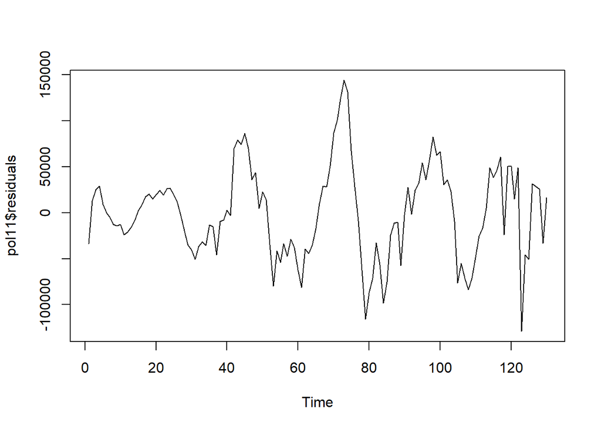

```r
plot.ts(pol11$residuals)
```

```r
detrend <- pol11$residuals
```

L’andamento dei residui non sembra essere molto influenzato dalla componente stagionale.

```r
seasVar <- as.factor(rep(1:4, 32))

SeasMod <- lm(detrend[1:128]  ~ -1 + seasVar)

summary(SeasMod)
```

```
##
## Call:
## lm(formula = detrend[1:128] ~ -1 + seasVar)
##
## Residuals:
##     Min      1Q  Median      3Q     Max
## -129951  -36257    -882   28550  152450
##
## Coefficients:
##          Estimate Std. Error t value Pr(>|t|)
## seasVar1  -8357.2     8933.2  -0.936    0.351
## seasVar2   8428.7     8933.2   0.944    0.347
## seasVar3    881.2     8933.2   0.099    0.922
## seasVar4   -422.5     8933.2  -0.047    0.962
##
## Residual standard error: 50530 on 124 degrees of freedom
## Multiple R-squared:  0.01413,    Adjusted R-squared:  -0.01767
## F-statistic: 0.4444 on 4 and 124 DF,  p-value: 0.7763
```

Tutti i coefficienti non sono significativamente diversi da 0, quindi la componente stagionale non è presente.

### Stima congiunta di trend e stagionalità

```r
AllTogMod <- lm(WFRBLB50085[1:128]  ~ I(1:128) + I((1:128)^2) + I((1:128)^3) + I((1:128)^4) + I((1:128)^5) + I((1:128)^6) + I((1:128)^7) + I((1:128)^8) + I((1:128)^9) + I((1:128)^10) + I((1:128)^11) + seasVar - 1)

summary(AllTogMod)
```

```
##
## Call:
## lm(formula = WFRBLB50085[1:128] ~ I(1:128) + I((1:128)^2) + I((1:128)^3) +
##     I((1:128)^4) + I((1:128)^5) + I((1:128)^6) + I((1:128)^7) +
##     I((1:128)^8) + I((1:128)^9) + I((1:128)^10) + I((1:128)^11) +
##     seasVar - 1)
##
## Residuals:
##     Min      1Q  Median      3Q     Max
## -129670  -35897    -702   28682  152356
##
## Coefficients:
##                 Estimate Std. Error t value Pr(>|t|)
## I(1:128)      -1.026e+05  4.566e+04  -2.246 0.026640 *
## I((1:128)^2)   2.965e+04  9.104e+03   3.256 0.001490 **
## I((1:128)^3)  -3.467e+03  8.671e+02  -3.998 0.000114 ***
## I((1:128)^4)   2.144e+02  4.651e+01   4.611 1.06e-05 ***
## I((1:128)^5)  -7.757e+00  1.533e+00  -5.061 1.63e-06 ***
## I((1:128)^6)   1.743e-01  3.252e-02   5.360 4.45e-07 ***
## I((1:128)^7)  -2.506e-03  4.526e-04  -5.537 2.03e-07 ***
## I((1:128)^8)   2.307e-05  4.106e-06   5.619 1.40e-07 ***
## I((1:128)^9)  -1.316e-07  2.337e-08  -5.630 1.33e-07 ***
## I((1:128)^10)  4.235e-10  7.576e-11   5.590 1.60e-07 ***
## I((1:128)^11) -5.879e-13  1.067e-13  -5.511 2.28e-07 ***
## seasVar1       6.430e+05  7.629e+04   8.429 1.28e-13 ***
## seasVar2       6.598e+05  7.698e+04   8.572 6.03e-14 ***
## seasVar3       6.522e+05  7.740e+04   8.427 1.29e-13 ***
## seasVar4       6.508e+05  7.768e+04   8.378 1.66e-13 ***
## ---
## Signif. codes:  0 '***' 0.001 '**' 0.01 '*' 0.05 '.' 0.1 ' ' 1
##
## Residual standard error: 52930 on 113 degrees of freedom
## Multiple R-squared:  0.9985, Adjusted R-squared:  0.9983
## F-statistic:  5148 on 15 and 113 DF,  p-value: < 2.2e-16
```

Si osservino ora i residui del modello.

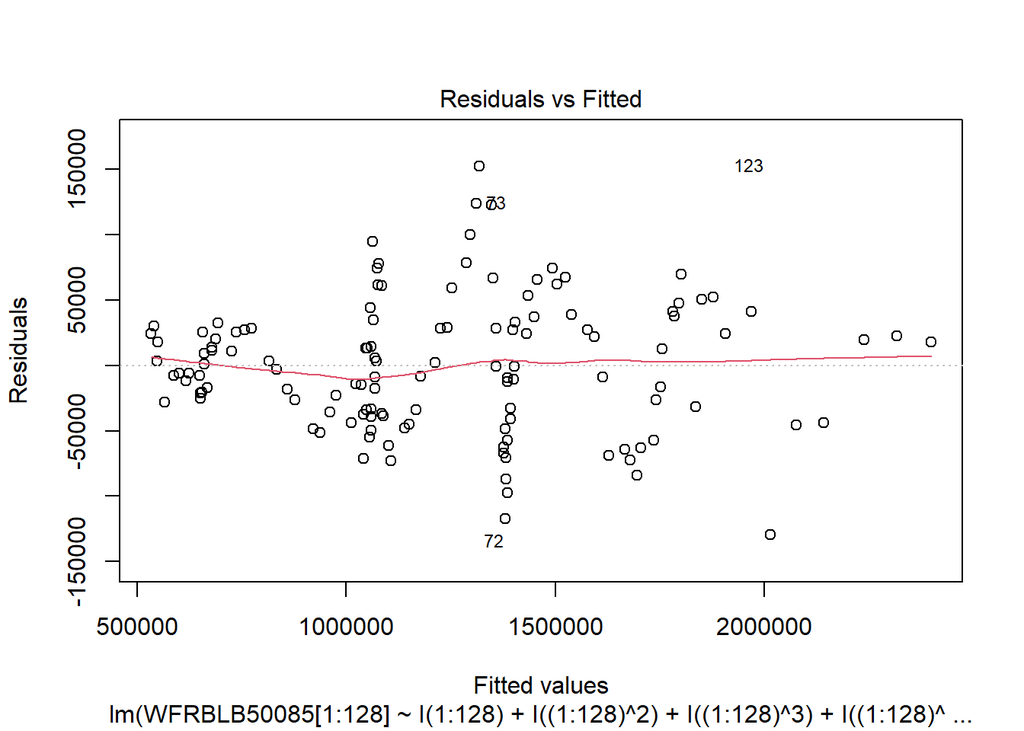

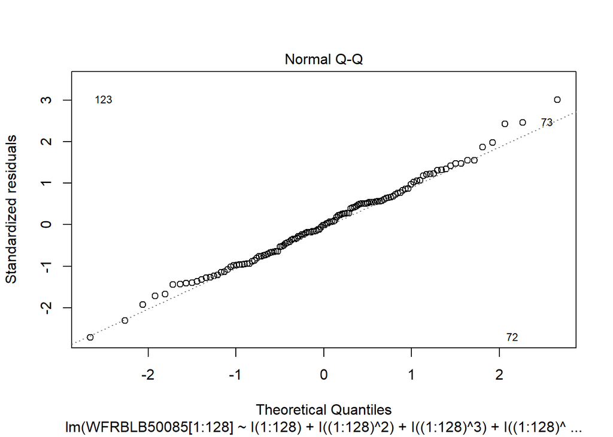

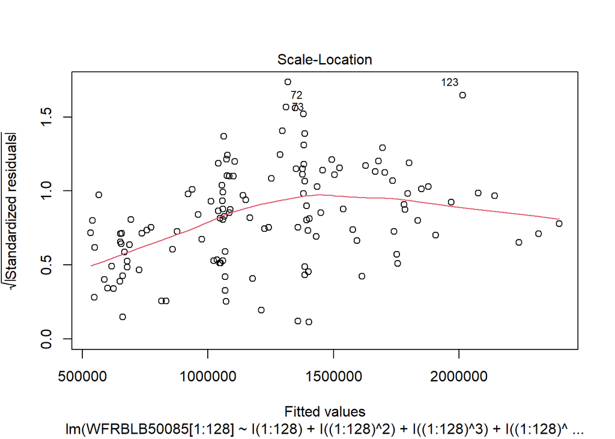

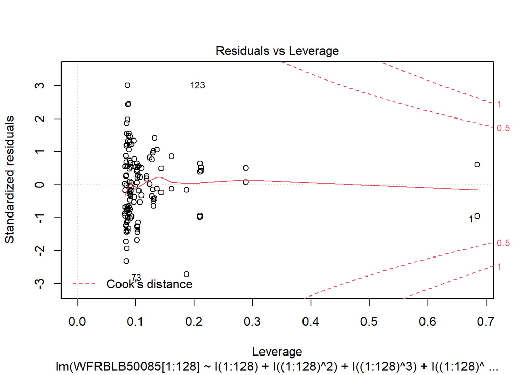

```r
plot(AllTogMod)
```

Osservando i grafici diagnostici si può notare che:

- Il grafico “Residual vs Fitted” mostra un andamento dei residui caratterizzato da una certa correlazione tra i residui
- Il grafico “Normal Q-Q” presenta dei valori che si avvicinano molto ai quantili della normale tranne per quanto riguarda le estremità
- Il grafico “Residual vs Leverage” mostra la distribuzione dei valori anomali. In questo caso non c’è una significativa presenza di valori anomali.

L’andamento dei residui non è casuale forse perché la componente tendenziale può essere meglio descritta tramite le medie mobili.

## Utilizzo di medie mobili

Si definisca la media mobile:

```r
mov.av <- function(x, m, cent=TRUE, diff.weig=FALSE, weig=NULL)
{
  res <- NULL
  if(cent==TRUE)
  {
    if(diff.weig==TRUE){weights <- weig} else
                       {weights <- rep(1/(2*m+1),(2*m+1))}
    for(i in (m+1):(length(x)-m))
    {res <- c(res, t(x[(i-m):(i+m)])%*%weights)}
  } else
  {
    if(diff.weig==TRUE){weights <- weig} else
                       {weights <- rep(1/(2*m),(2*m))}
    for(i in 0:(length(x)-2*m))
    {res <- c(res, t(x[(1:(2*m))+i])%*%weights)}
  }
  return(res)
}
```

Utilizzo una media mobile di ordine 4 centrata poiché i dati sono trimestrali.

```r
MM4c <- mov.av(mov.av(WFRBLB50085, m=2, cent=FALSE), m=1, cent=FALSE)

res_ST <- WFRBLB50085[-c(1:2,129:130)] - MM4c
```

Calcolo le medie mobili di periodo:

```r
SeasMod <- lm(res_ST ~ - 1 + seasVar[-c(1:2,129:130)])

summary(SeasMod)
```

```
##
## Call:
## lm(formula = res_ST ~ -1 + seasVar[-c(1:2, 129:130)])
##
## Residuals:
##     Min      1Q  Median      3Q     Max
## -100096   -6231     873    8993   50046
##
## Coefficients:
##                            Estimate Std. Error t value Pr(>|t|)
## seasVar[-c(1:2, 129:130)]1 -7895.25    3148.03  -2.508   0.0135 *
## seasVar[-c(1:2, 129:130)]2  8005.45    3148.03   2.543   0.0122 *
## seasVar[-c(1:2, 129:130)]3    76.34    3098.45   0.025   0.9804
## seasVar[-c(1:2, 129:130)]4  -921.93    3098.45  -0.298   0.7666
## ---
## Signif. codes:  0 '***' 0.001 '**' 0.01 '*' 0.05 '.' 0.1 ' ' 1
##
## Residual standard error: 17530 on 122 degrees of freedom
## Multiple R-squared:  0.09526,    Adjusted R-squared:  0.0656
## F-statistic: 3.212 on 4 and 122 DF,  p-value: 0.01517
```

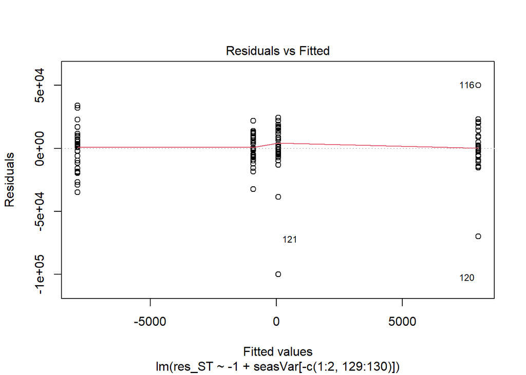

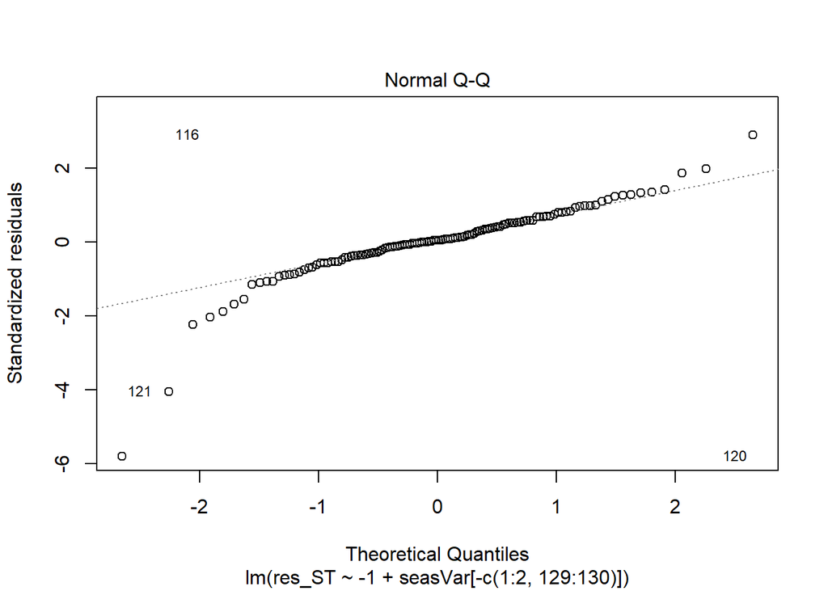

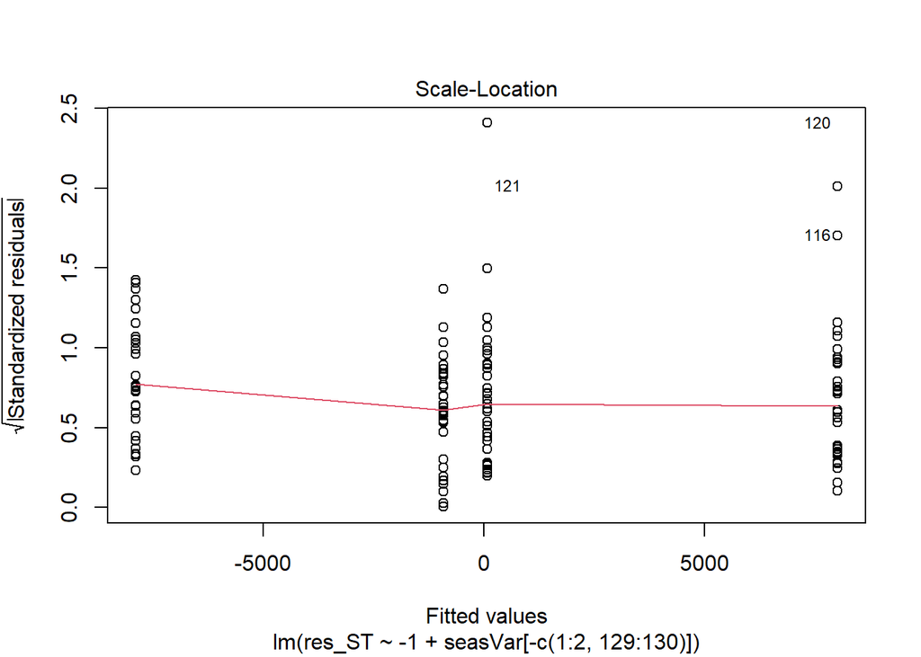

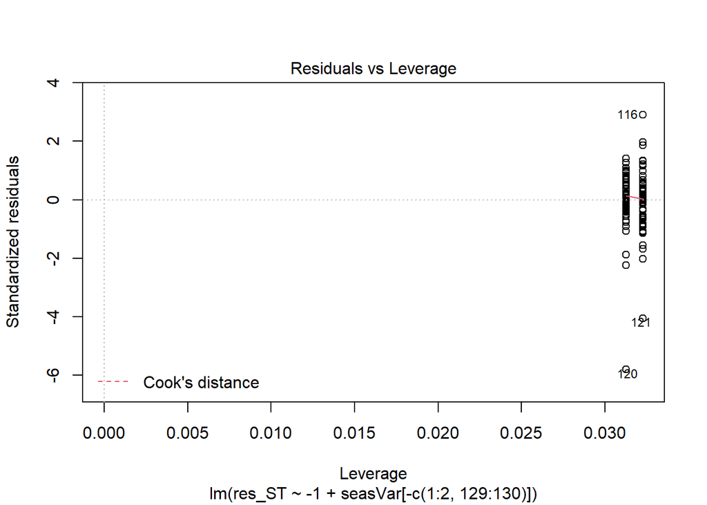

```r
plot(SeasMod)
```

### Osservazione dei risultati dal punto di vista grafico

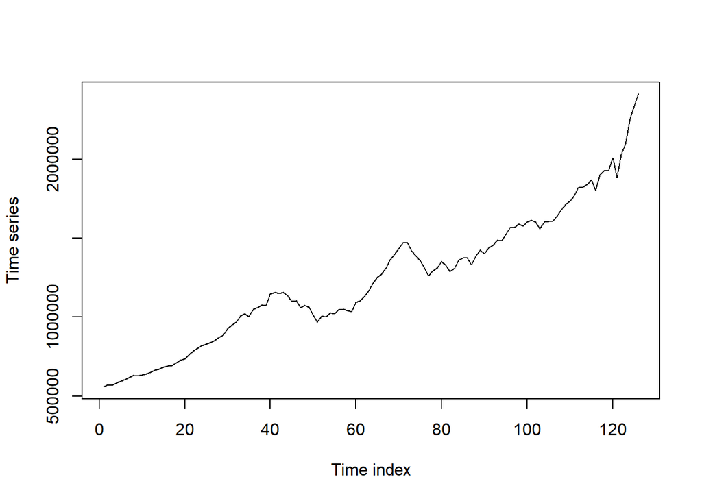

```r
plot(as.vector(WFRBLB50085[-c(1:2,129:130)]), type = "l", ylab = "Time series", xlab = "Time index")
```

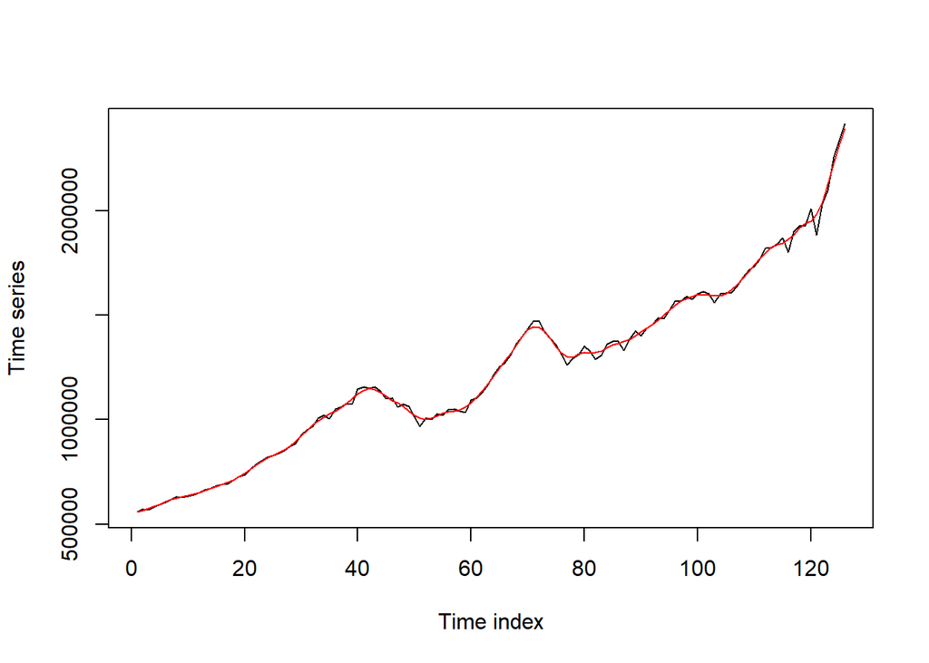

```r
plot(as.vector(WFRBLB50085[-c(1:2,129:130)]), type = "l", ylab = "Time series", xlab = "Time index")
lines(MM4c, col="red")
```

## Scomposizione con R

Utilizzo il comando decompose:

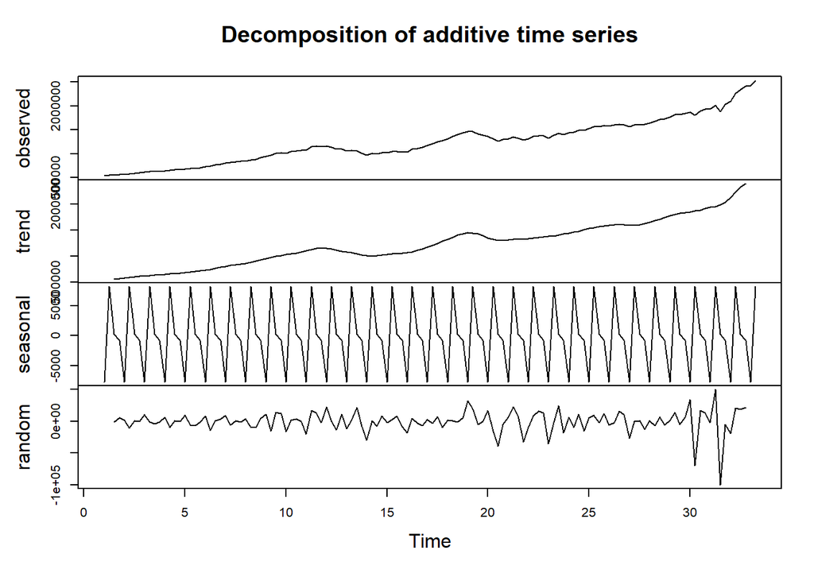

```r
WFRBLB50085 <- ts(as.vector(WFRBLB50085), frequency = 4, deltat = 1/4)

res1 <- decompose(WFRBLB50085)

plot(res1)
```

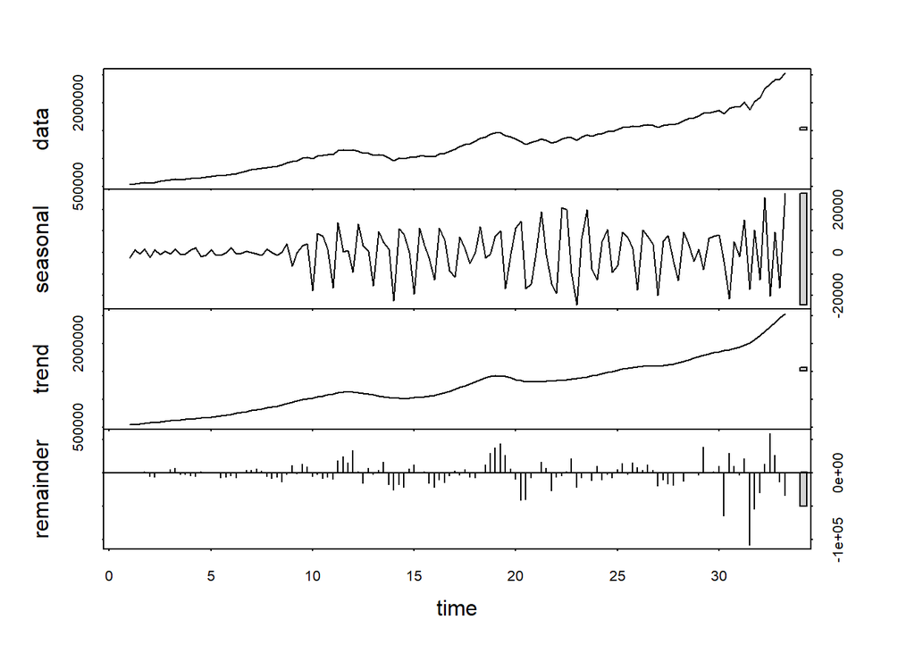

```r
res <- stl(WFRBLB50085, s.window = 4)

plot(res)
```

Osservando queste scomposizioni, si nota come non c’è coerenza tra il comando “decompose” e il comando “stl” per quanto riguarda la componente stagionale. Ciò significa che la stagionalità è poco evidente all’interno dei dati.

### Analisi del residuo

Osservo i grafici riguardanti l’autocorrelazione e la correlazione parziale:

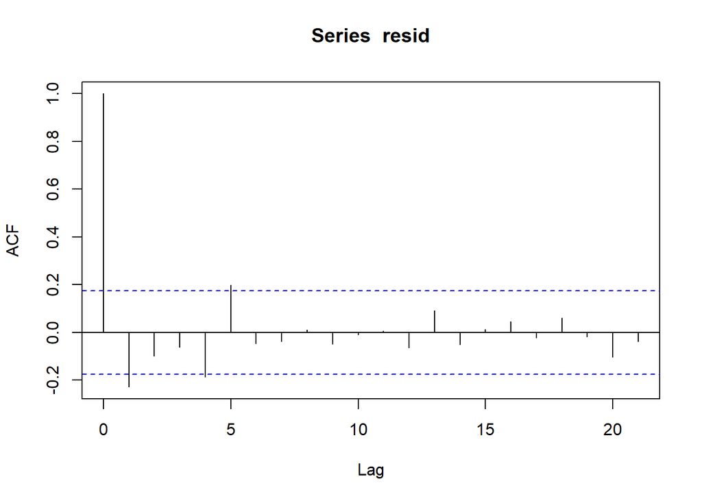

```r
resid <- res1$random
resid <- resid[!is.na(resid)]

acf(resid)
```

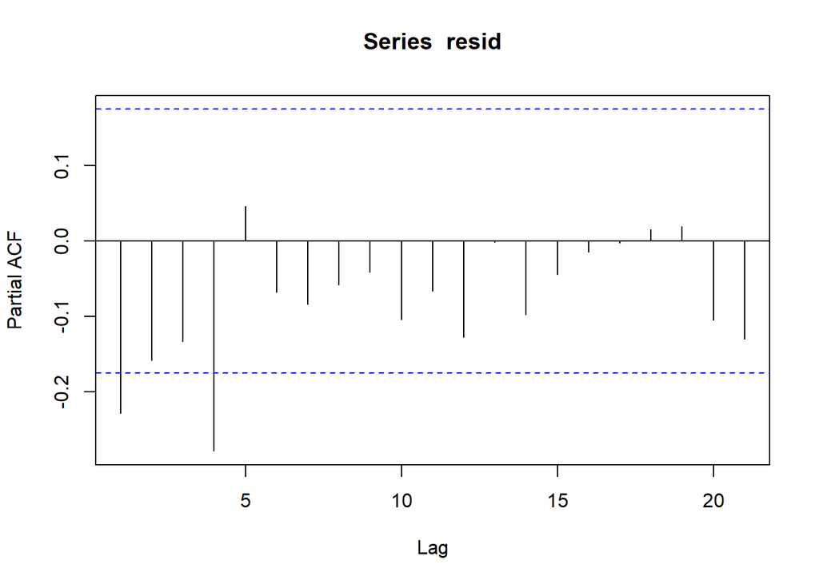

```r
pacf(resid)
```

Dai grafici dell’autocorrelazione e dell’autocorrelazione parziale è possibile vedere che, siccome alcuni valori escono dalla banda di tolleranza, è presente autocorrelazione dei residui, tenendo presente che il primo valore è sempre pari a 1.

Ora valuto la casualità nella distribuzione dei residui attraverso il Box Test:

```r
?Box.test
```

```
## starting httpd help server ... done
```

```r
Box.test(resid)
```

```
##
##  Box-Pierce test
##
## data:  resid
## X-squared = 6.5588, df = 1, p-value = 0.01044
```

Il test d’ipotesi presenta un p-value, che rappresenta il livello di significatività osservata, di 0,01. Siccome il p-value è inferiore ad alfa = 0,05 , rifiuto l’ipotesi nulla di indipendenza dei residui.